# Capstone Project: Create a Customer Segmentation Report for Arvato Financial Services

In this project, you will analyze demographics data for customers of a mail-order sales company in Germany, comparing it against demographics information for the general population. You'll use unsupervised learning techniques to perform customer segmentation, identifying the parts of the population that best describe the core customer base of the company. Then, you'll apply what you've learned on a third dataset with demographics information for targets of a marketing campaign for the company, and use a model to predict which individuals are most likely to convert into becoming customers for the company. The data that you will use has been provided by our partners at Bertelsmann Arvato Analytics, and represents a real-life data science task.

If you completed the first term of this program, you will be familiar with the first part of this project, from the unsupervised learning project. The versions of those two datasets used in this project will include many more features and has not been pre-cleaned. You are also free to choose whatever approach you'd like to analyzing the data rather than follow pre-determined steps. In your work on this project, make sure that you carefully document your steps and decisions, since your main deliverable for this project will be a blog post reporting your findings.

```python
# import libraries here; add more as necessary
import numpy as np
import pandas as pd
import matplotlib.pyplot as plt
import seaborn as sns

# magic word for producing visualizations in notebook
%matplotlib inline
import seaborn as sb

# Other libraries
from sklearn.preprocessing import StandardScaler
from sklearn.decomposition import PCA
import operator
from sklearn.cluster import KMeans
from sklearn.model_selection import RandomizedSearchCV
from sklearn.metrics import classification_report
from sklearn.model_selection import train_test_split
from sklearn.naive_bayes import MultinomialNB
from sklearn.ensemble import BaggingClassifier, RandomForestClassifier, AdaBoostClassifier
from sklearn.svm import SVC
from sklearn.linear_model import SGDClassifier

import warnings
warnings.filterwarnings("ignore")
```

## Part 0: Get to Know the Data

Each row of the demographics files represents a single person, but also includes information outside of individuals, including information about their household, building, and neighborhood. Use the information from the first two files to figure out how customers ("CUSTOMERS") are similar to or differ from the general population at large ("AZDIAS"), then use your analysis to make predictions on the other two files ("MAILOUT"), predicting which recipients are most likely to become a customer for the mail-order company.

The "CUSTOMERS" file contains three extra columns ('CUSTOMER_GROUP', 'ONLINE_PURCHASE', and 'PRODUCT_GROUP'), which provide broad information about the customers depicted in the file. The original "MAILOUT" file included one additional column, "RESPONSE", which indicated whether or not each recipient became a customer of the company. For the "TRAIN" subset, this column has been retained, but in the "TEST" subset it has been removed; it is against that withheld column that your final predictions will be assessed in the Kaggle competition.

Otherwise, all of the remaining columns are the same between the three data files. For more information about the columns depicted in the files, you can refer to two Excel spreadsheets provided in the workspace. One of them is a top-level list of attributes and descriptions, organized by informational category. The other is a detailed mapping of data values for each feature in alphabetical order.

In the below cell, we've provided some initial code to load in the first two datasets. Note for all of the `.csv` data files in this project that they're semicolon (`;`) delimited, so an additional argument in the [`read_csv()`](https://pandas.pydata.org/pandas-docs/stable/generated/pandas.read_csv.html) call has been included to read in the data properly. Also, considering the size of the datasets, it may take some time for them to load completely.

You'll notice when the data is loaded in that a warning message will immediately pop up. Before you really start digging into the modeling and analysis, you're going to need to perform some cleaning. Take some time to browse the structure of the data and look over the informational spreadsheets to understand the data values. Make some decisions on which features to keep, which features to drop, and if any revisions need to be made on data formats. It'll be a good idea to create a function with pre-processing steps, since you'll need to clean all of the datasets before you work with them.

```python
# load in the general population data
azdias = pd.read_csv('data/Udacity_AZDIAS_052018.csv')
```

### 0.1: Data Analysis/Understanding (Data Exploration/Visualization)

As mentioned at above, the customers datasets contains three extra columns ('CUSTOMER_GROUP', 'ONLINE_PURCHASE', and 'PRODUCT_GROUP'), which provide broad information about the customers depicted in the file. In addition, the mailout_train included one additional column, "RESPONSE", which indicated whether or not each recipient became a customer of the company.

```python
# Checking for the general demographics data
print('Number of row and column recorded at the general demographics data are {} and {} respectively.'.format(azdias.shape[0], azdias.shape[1]))
azdias.head()
```

```
Number of row and column recorded at the general demographics data are 891221 and 366 respectively.
```

|  | LNR | AGER_TYP | AKT_DAT_KL | ALTER_HH | ALTER_KIND1 | ALTER_KIND2 | ALTER_KIND3 | ALTER_KIND4 | ALTERSKATEGORIE_FEIN | ANZ_HAUSHALTE_AKTIV | ... | VHN | VK_DHT4A | VK_DISTANZ | VK_ZG11 | W_KEIT_KIND_HH | WOHNDAUER_2008 | WOHNLAGE | ZABEOTYP | ANREDE_KZ | ALTERSKATEGORIE_GROB |
| --- | --- | --- | --- | --- | --- | --- | --- | --- | --- | --- | --- | --- | --- | --- | --- | --- | --- | --- | --- | --- | --- |
| 0 | 910215 | -1 | NaN | NaN | NaN | NaN | NaN | NaN | NaN | NaN | ... | NaN | NaN | NaN | NaN | NaN | NaN | NaN | 3 | 1 | 2 |
| 1 | 910220 | -1 | 9.0 | 0.0 | NaN | NaN | NaN | NaN | 21.0 | 11.0 | ... | 4.0 | 8.0 | 11.0 | 10.0 | 3.0 | 9.0 | 4.0 | 5 | 2 | 1 |
| 2 | 910225 | -1 | 9.0 | 17.0 | NaN | NaN | NaN | NaN | 17.0 | 10.0 | ... | 2.0 | 9.0 | 9.0 | 6.0 | 3.0 | 9.0 | 2.0 | 5 | 2 | 3 |
| 3 | 910226 | 2 | 1.0 | 13.0 | NaN | NaN | NaN | NaN | 13.0 | 1.0 | ... | 0.0 | 7.0 | 10.0 | 11.0 | NaN | 9.0 | 7.0 | 3 | 2 | 4 |
| 4 | 910241 | -1 | 1.0 | 20.0 | NaN | NaN | NaN | NaN | 14.0 | 3.0 | ... | 2.0 | 3.0 | 5.0 | 4.0 | 2.0 | 9.0 | 3.0 | 4 | 1 | 3 |

5 rows × 366 columns

#### 0.1.1 Access Missing Data

```python
# check if the azdias dataframe has missing data
azdias.info(null_counts=True, verbose=True)
```

```
<class 'pandas.core.frame.DataFrame'>
RangeIndex: 891221 entries, 0 to 891220
Data columns (total 366 columns):
LNR                            891221 non-null int64
AGER_TYP                       891221 non-null int64
AKT_DAT_KL                     817722 non-null float64
ALTER_HH                       817722 non-null float64
ALTER_KIND1                    81058 non-null float64
ALTER_KIND2                    29499 non-null float64
ALTER_KIND3                    6170 non-null float64
ALTER_KIND4                    1205 non-null float64
ALTERSKATEGORIE_FEIN           628274 non-null float64
ANZ_HAUSHALTE_AKTIV            798073 non-null float64
ANZ_HH_TITEL                   794213 non-null float64
ANZ_KINDER                     817722 non-null float64
ANZ_PERSONEN                   817722 non-null float64
ANZ_STATISTISCHE_HAUSHALTE     798073 non-null float64
ANZ_TITEL                      817722 non-null float64
ARBEIT                         794005 non-null float64
BALLRAUM                       797481 non-null float64
CAMEO_DEU_2015                 792242 non-null object
CAMEO_DEUG_2015                792242 non-null object
CAMEO_INTL_2015                792242 non-null object
CJT_GESAMTTYP                  886367 non-null float64
CJT_KATALOGNUTZER              886367 non-null float64
CJT_TYP_1                      886367 non-null float64
CJT_TYP_2                      886367 non-null float64
CJT_TYP_3                      886367 non-null float64
CJT_TYP_4                      886367 non-null float64
CJT_TYP_5                      886367 non-null float64
CJT_TYP_6                      886367 non-null float64
D19_BANKEN_ANZ_12              891221 non-null int64
D19_BANKEN_ANZ_24              891221 non-null int64
D19_BANKEN_DATUM               891221 non-null int64
D19_BANKEN_DIREKT              891221 non-null int64
D19_BANKEN_GROSS               891221 non-null int64
D19_BANKEN_LOKAL               891221 non-null int64
D19_BANKEN_OFFLINE_DATUM       891221 non-null int64
D19_BANKEN_ONLINE_DATUM        891221 non-null int64
D19_BANKEN_ONLINE_QUOTE_12     634108 non-null float64
```

[output cut: 316 more lines]

```
VERDICHTUNGSRAUM               793947 non-null float64
VERS_TYP                       891221 non-null int64
VHA                            817722 non-null float64
VHN                            770025 non-null float64
VK_DHT4A                       815304 non-null float64
VK_DISTANZ                     815304 non-null float64
VK_ZG11                        815304 non-null float64
W_KEIT_KIND_HH                 783619 non-null float64
WOHNDAUER_2008                 817722 non-null float64
WOHNLAGE                       798073 non-null float64
ZABEOTYP                       891221 non-null int64
ANREDE_KZ                      891221 non-null int64
ALTERSKATEGORIE_GROB           891221 non-null int64
dtypes: float64(267), int64(93), object(6)
memory usage: 2.4+ GB
```

> the output above show that azdias dataframes have missing data. Let's carry out further exploration for these missing data at the subsequent sections.

##### 0.1.1.1 Access Missing Data in Each Column

Perform an assessment of how much missing data there is in each column of the dataset.

```python
# count missing data for each column and define it as data_missing_count
data_missing_count = azdias.isnull().sum()
data_missing_count
```

```
LNR                                0
AGER_TYP                           0
AKT_DAT_KL                     73499
ALTER_HH                       73499
ALTER_KIND1                   810163
ALTER_KIND2                   861722
ALTER_KIND3                   885051
ALTER_KIND4                   890016
ALTERSKATEGORIE_FEIN          262947
ANZ_HAUSHALTE_AKTIV            93148
ANZ_HH_TITEL                   97008
ANZ_KINDER                     73499
ANZ_PERSONEN                   73499
ANZ_STATISTISCHE_HAUSHALTE     93148
ANZ_TITEL                      73499
ARBEIT                         97216
BALLRAUM                       93740
CAMEO_DEU_2015                 98979
CAMEO_DEUG_2015                98979
CAMEO_INTL_2015                98979
CJT_GESAMTTYP                   4854
CJT_KATALOGNUTZER               4854
CJT_TYP_1                       4854
CJT_TYP_2                       4854
CJT_TYP_3                       4854
CJT_TYP_4                       4854
CJT_TYP_5                       4854
CJT_TYP_6                       4854
D19_BANKEN_ANZ_12                  0
D19_BANKEN_ANZ_24                  0
                               ...
SEMIO_KRIT                         0
SEMIO_KULT                         0
SEMIO_LUST                         0
SEMIO_MAT                          0
SEMIO_PFLICHT                      0
SEMIO_RAT                          0
SEMIO_REL                          0
SEMIO_SOZ                          0
SEMIO_TRADV                        0
SEMIO_VERT                         0
SHOPPER_TYP                        0
SOHO_KZ                        73499
STRUKTURTYP                    97274
TITEL_KZ                       73499
UMFELD_ALT                     97786
UMFELD_JUNG                    97786
UNGLEICHENN_FLAG               73499
VERDICHTUNGSRAUM               97274
VERS_TYP                           0
VHA                            73499
VHN                           121196
VK_DHT4A                       75917
VK_DISTANZ                     75917
VK_ZG11                        75917
W_KEIT_KIND_HH                107602
WOHNDAUER_2008                 73499
WOHNLAGE                       93148
ZABEOTYP                           0
ANREDE_KZ                          0
ALTERSKATEGORIE_GROB               0
Length: 366, dtype: int64
```

Series above shows total number of missing value counts of each feature/column of our datasets.

```python
# Investigate patterns in the amount of missing data in each column.

# obtain series, which has missing data count
# define it as data_missing_count_morethan0
data_missing_count_morethan0 = data_missing_count[data_missing_count!=0]

# calculate the number of fetures, which have missing data
num_missing_feature = len(data_missing_count_morethan0)
print('The number of features, which have missing values is {}.'.format(num_missing_feature))
```

```
The number of features, which have missing values is 273.
```

```python
# print out all features which have missing values
data_missing_count_morethan0.index
```

```
Index(['AKT_DAT_KL', 'ALTER_HH', 'ALTER_KIND1', 'ALTER_KIND2', 'ALTER_KIND3',
       'ALTER_KIND4', 'ALTERSKATEGORIE_FEIN', 'ANZ_HAUSHALTE_AKTIV',
       'ANZ_HH_TITEL', 'ANZ_KINDER',
       ...
       'UNGLEICHENN_FLAG', 'VERDICHTUNGSRAUM', 'VHA', 'VHN', 'VK_DHT4A',
       'VK_DISTANZ', 'VK_ZG11', 'W_KEIT_KIND_HH', 'WOHNDAUER_2008',
       'WOHNLAGE'],
      dtype='object', length=273)
```

The output above presents all features, which have missing values.

A bar chart is used to depict the distribution of missing value counts of features, as the feature of datasets is categorical variable.

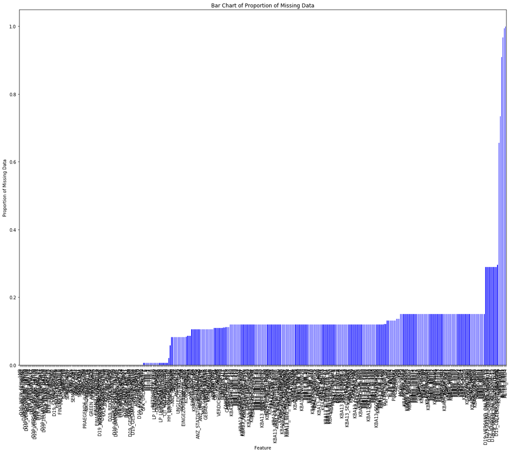

```python
# sort the data_missing_count
data_missing_count = data_missing_count.sort_values()

# calculate the proportion of data missing count
data_missing_prop = data_missing_count/azdias.shape[0]

# plot bar chart for data_missing_count
data_missing_prop.plot.bar(figsize=(20,15), color = 'b')

# add title, x-label and y-label into plot
plt.title('Bar Chart of Proportion of Missing Data')
plt.xlabel('Feature')
plt.ylabel('Proportion of Missing Data');
```

> Although the chart above is unable to present the features that have higher missing data clearly, we still could notice that there are some features that have more than 20 % of missing data.

> Let's zoom it for features that have more than 20% of datasets.

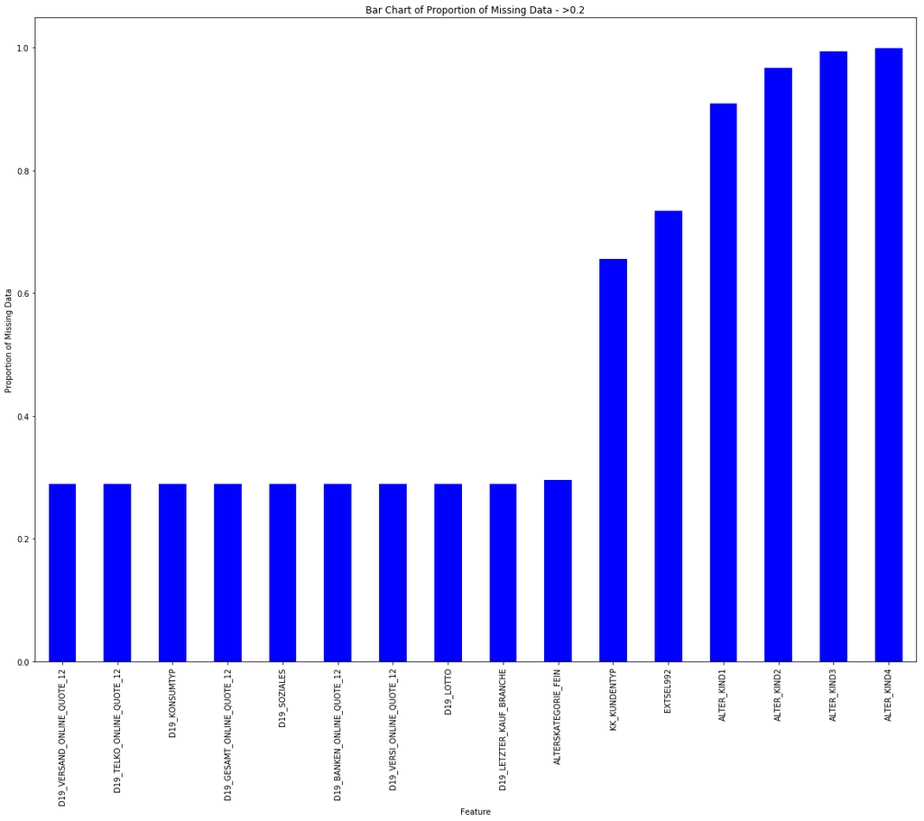

```python
# plotting for data_missing_count_prop which more than 0.2 of datasets (row)

# gain high proportion missing data
data_missing_prop_high = data_missing_prop[data_missing_prop>0.2]

# plot bar chart for data_missing_count
data_missing_prop_high.plot.bar(figsize=(20,15), color = 'b')

# add title, x-label and y-label into plot
plt.title('Bar Chart of Proportion of Missing Data - >0.2')
plt.xlabel('Feature')
plt.ylabel('Proportion of Missing Data');
```

```python
# calculate number of features that have higher missing data proportion.
print(len(data_missing_prop_high))

# print out all features that have high proportion of missing data
data_missing_prop_high
```

```
16
```

```
D19_VERSAND_ONLINE_QUOTE_12    0.288495
D19_TELKO_ONLINE_QUOTE_12      0.288495
D19_KONSUMTYP                  0.288495
D19_GESAMT_ONLINE_QUOTE_12     0.288495
D19_SOZIALES                   0.288495
D19_BANKEN_ONLINE_QUOTE_12     0.288495
D19_VERSI_ONLINE_QUOTE_12      0.288495
D19_LOTTO                      0.288495
D19_LETZTER_KAUF_BRANCHE       0.288495
ALTERSKATEGORIE_FEIN           0.295041
KK_KUNDENTYP                   0.655967
EXTSEL992                      0.733996
ALTER_KIND1                    0.909048
ALTER_KIND2                    0.966900
ALTER_KIND3                    0.993077
ALTER_KIND4                    0.998648
dtype: float64
```

Both bar charts above show the pattern of proportion of missing value of each features of our datasets.

From bar chart (>0.2 proportion), we could notice that there are 16 features have higher missing value proportion, which are up to 99.9%

Therefore, I will drop these 16 features from our datasets at below.

```python
data_missing_prop_high.index
```

```
Index(['D19_VERSAND_ONLINE_QUOTE_12', 'D19_TELKO_ONLINE_QUOTE_12',
       'D19_KONSUMTYP', 'D19_GESAMT_ONLINE_QUOTE_12', 'D19_SOZIALES',
       'D19_BANKEN_ONLINE_QUOTE_12', 'D19_VERSI_ONLINE_QUOTE_12', 'D19_LOTTO',
       'D19_LETZTER_KAUF_BRANCHE', 'ALTERSKATEGORIE_FEIN', 'KK_KUNDENTYP',
       'EXTSEL992', 'ALTER_KIND1', 'ALTER_KIND2', 'ALTER_KIND3',
       'ALTER_KIND4'],
      dtype='object')
```

```python
# drop features (which have higher missing values) from azdias
azdias = azdias.drop(
                    ['D19_VERSAND_ONLINE_QUOTE_12', 'D19_TELKO_ONLINE_QUOTE_12',
                    'D19_KONSUMTYP', 'D19_GESAMT_ONLINE_QUOTE_12', 'D19_SOZIALES',
                    'D19_BANKEN_ONLINE_QUOTE_12', 'D19_VERSI_ONLINE_QUOTE_12', 'D19_LOTTO',
                    'D19_LETZTER_KAUF_BRANCHE', 'ALTERSKATEGORIE_FEIN', 'KK_KUNDENTYP',
                    'EXTSEL992', 'ALTER_KIND1', 'ALTER_KIND2', 'ALTER_KIND3',
                    'ALTER_KIND4']
                    , axis=1)
```

```python
# check if the drop() is successful
len(azdias.columns)
```

```
350
```

##### 0.1.1.2 Access Missing Data in Each Row

Now, we'll perform a similar assessment for the rows of the dataset.

```python
# How much data is missing in each row of the dataset?

# count missing data for each row and define it as data_missing_count_row
data_missing_count_row = azdias.isnull().sum(axis=1)
data_missing_count_row
```

```
0         236
1           0
2           0
3           2
4           0
5           0
6           0
7           0
8           0
9           0
10          0
11        237
12         64
13         67
14        237
```

[output cut: 47 more lines]

> Series above shows the total missing value count of each row of our datasets.

```python
# obtain series, which has missing data count
# define it as data_missing_count_morethan0
data_missing_count_row_morethan0 = data_missing_count_row[data_missing_count_row!=0]

# calculate the number of fetures, which have missing data
num_missing_count_row = len(data_missing_count_row_morethan0)
percent_missing_count_row = len(data_missing_count_row_morethan0)/891221*100

# print out the results
print('Total number of row, which have missing values is {}.'.format(num_missing_count_row))
print('Percent of row, which have missing values is {0:5.2f}%.'.format(percent_missing_count_row))
```

```
Total number of row, which have missing values is 194279.
Percent of row, which have missing values is 21.80%.
```

```python
data_missing_count_row.describe()
```

```
count    891221.000000
mean         29.431804
std          73.177219
min           0.000000
25%           0.000000
50%           0.000000
75%           0.000000
max         244.000000
dtype: float64
```

> Based on descriptive statistics above, the maximum of missing data count could be up to 244. Therefore, we could divide the data into two subsets by using <= 120 missing data counts and > 120 missing data counts.

```python
# Write code to divide the data into two subsets based on the number of missing
# values in each row.

# create dataframe which have few or no missing value counts of row
dataframe_missing_few_or_no = azdias[azdias.isnull().sum(axis=1) <= 120]

# create dataframe which have many missing value counts of row
dataframe_missing_many = azdias[azdias.isnull().sum(axis=1) > 120]
```

```python
# searching columns that are not missing data
data_missing_count_0 = data_missing_count[data_missing_count==0]
data_missing_count_0
```

```
LNR                          0
D19_WEIN_FEINKOST            0
D19_VOLLSORTIMENT            0
D19_VERSICHERUNGEN           0
D19_VERSI_ONLINE_DATUM       0
D19_VERSI_OFFLINE_DATUM      0
D19_VERSI_DATUM              0
D19_VERSI_ANZ_24             0
D19_VERSI_ANZ_12             0
D19_VERSAND_REST             0
D19_VERSAND_ONLINE_DATUM     0
D19_VERSAND_OFFLINE_DATUM    0
D19_VERSAND_DATUM            0
D19_VERSAND_ANZ_24           0
D19_VERSAND_ANZ_12           0
D19_TIERARTIKEL              0
D19_TELKO_REST               0
D19_TELKO_ONLINE_DATUM       0
D19_TELKO_OFFLINE_DATUM      0
D19_TELKO_MOBILE             0
D19_TELKO_DATUM              0
D19_TELKO_ANZ_24             0
D19_TELKO_ANZ_12             0
D19_TECHNIK                  0
D19_SONSTIGE                 0
D19_SCHUHE                   0
D19_SAMMELARTIKEL            0
D19_REISEN                   0
FINANZ_ANLEGER               0
D19_RATGEBER                 0
                            ..
D19_BANKEN_DATUM             0
D19_DIGIT_SERV               0
D19_BUCH_CD                  0
D19_BIO_OEKO                 0
D19_BILDUNG                  0
D19_BEKLEIDUNG_REST          0
D19_ENERGIE                  0
D19_BEKLEIDUNG_GEH           0
D19_BANKEN_ONLINE_DATUM      0
D19_BANKEN_OFFLINE_DATUM     0
D19_BANKEN_LOKAL             0
D19_BANKEN_GROSS             0
D19_BANKEN_ANZ_12            0
D19_BANKEN_ANZ_24            0
D19_BANKEN_REST              0
D19_FREIZEIT                 0
D19_BANKEN_DIREKT            0
D19_GESAMT_ANZ_12            0
D19_GESAMT_ANZ_24            0
D19_GESAMT_DATUM             0
D19_GESAMT_OFFLINE_DATUM     0
D19_LEBENSMITTEL             0
D19_GESAMT_ONLINE_DATUM      0
D19_KOSMETIK                 0
D19_HANDWERK                 0
D19_GARTEN                   0
D19_HAUS_DEKO                0
D19_KONSUMTYP_MAX            0
D19_KINDERARTIKEL            0
AGER_TYP                     0
Length: 93, dtype: int64
```

> Output above shows columns that are not missing data. Let's select the following columns for this assessment.
> - D19_SONSTIGE
> - FINANZ_SPARER
> - ZABEOTYP
> - AGER_TYP
> - SEMIO_DOM

```python
# Compare the distribution of values for at least five columns where there are
# no or few missing values, between the two subsets.

# Create Function for plotting countplot
def plot(col):
    '''plot countplot for each col

    Arg:
    col: string. features name

    Return:
    Bar Chart Plot: object. Countplot of missing data for feature.

    '''

    f, axes = plt.subplots(1, 2,sharey=True)

    sns.countplot(dataframe_missing_few_or_no[col], ax=axes[0])
    axes[0].set_title('No or Few Missing Value')

    sns.countplot(dataframe_missing_many[col], ax=axes[1])
    axes[1].set_title('Many Missing Value')
```

`Distribution of D19_SONSTIGE`

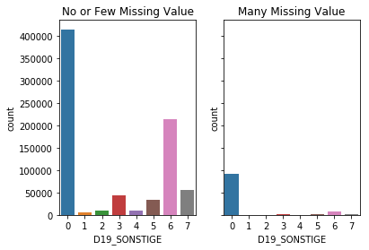

```python
# Compare the distribution of missing value counts of 'D19_SONSTIGE' columns between the two subsets
plot('D19_SONSTIGE')
```

`Distribution of FINANZ_SPARER`

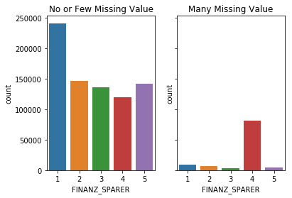

```python
# Compare the distribution of missing value counts of 'FINANZ_SPARER' columns between the two subsets
plot('FINANZ_SPARER')
```

`Distribution of ZABEOTYP`

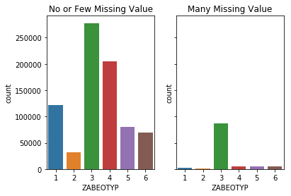

```python
# Compare the distribution of missing value counts of 'ZABEOTYP' columns between the two subsets
plot('ZABEOTYP')
```

`Distribution of AGER_TYP`

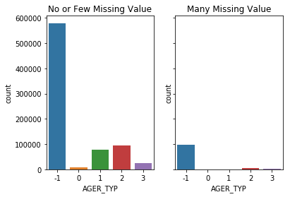

```python
# Compare the distribution of missing value counts of 'AGER_TYP' columns between the two subsets
plot('AGER_TYP')
```

`Distribution of SEMIO_DOM`

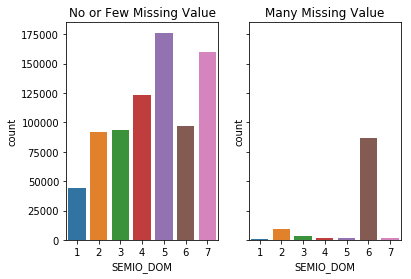

```python
# Compare the distribution of missing value counts of 'SEMIO_DOM' columns between the two subsets
plot('SEMIO_DOM')
```

```python
# if select datasets with few or no missing values (dataframe_missing_few_or_no),
# how many rows will be removed? how many percent of row will be removed?

number_row_removed = 891221 - dataframe_missing_few_or_no.shape[0]
percent_row_removed = number_row_removed/891221 * 100

print('The number and percent of row removed are {} rows and {:5.2f} % respectively'.format(number_row_removed,percent_row_removed))
```

```
The number and percent of row removed are 105159 rows and 11.80 % respectively
```

> From these 5 subplots above, we could noticed that the data with > 120 (many) missing values looks very different from the data with <=120 (few or no) missing values. Hence, it should be noted that our datasets are special.

> Therefore, let's continue our analysis by using this datasets with few or no missing values features (dataframe_missing_few_or_no).

> However, sklearn requires that data not have missing values in order for its estimators to work properly. Therefore, let's impute all remaining missing value from our datasets, as shown at below.

```python
 # Impute the remaing missing data with each column's mode values
for column in dataframe_missing_few_or_no.columns:
    dataframe_missing_few_or_no[column] = dataframe_missing_few_or_no[column].fillna(dataframe_missing_few_or_no[column].mode()[0])
```

```python
# check if all missing values had been imputed
dataframe_missing_few_or_no.isnull().sum().sum()
```

```
0
```

```python
# change dataframe_missing_few_or_no to df_azdias
df_azdias = dataframe_missing_few_or_no
```

#### 0.1.2 Create Clear Missing Data Function

```python
def clean_missing_data(df):
    '''clear all missing data from dataframe

    Args:
    df: DataFrame. DataFrame needed to be cleared

    Returns:
    df: DataFrame. DataFrame had be cleared

    '''

    # Clean Column that have more than 0.2 of missing data====================================================================

    # drop features (which have higher missing values) from df
    df = df.drop(
                    ['D19_VERSAND_ONLINE_QUOTE_12', 'D19_TELKO_ONLINE_QUOTE_12',
                    'D19_KONSUMTYP', 'D19_GESAMT_ONLINE_QUOTE_12', 'D19_SOZIALES',
                    'D19_BANKEN_ONLINE_QUOTE_12', 'D19_VERSI_ONLINE_QUOTE_12', 'D19_LOTTO',
                    'D19_LETZTER_KAUF_BRANCHE', 'ALTERSKATEGORIE_FEIN', 'KK_KUNDENTYP',
                    'EXTSEL992', 'ALTER_KIND1', 'ALTER_KIND2', 'ALTER_KIND3',
                    'ALTER_KIND4']
                    , axis=1)

    # Clear Row that have many missing value==================================================================================

    # create dataframe which have few or no of missing value counts of row
    dataframe_missing_few_or_no = df[df.isnull().sum(axis=1) <= 120]

    # Impute the remaing missing data with each column's mode values================================================================================
    for column in dataframe_missing_few_or_no.columns:
        dataframe_missing_few_or_no[column] = dataframe_missing_few_or_no[column].fillna(dataframe_missing_few_or_no[column].mode()[0])

    # change dataframe_missing_few_or_no to df
    df = dataframe_missing_few_or_no

    return df
```

### 0.2: Data Preparation/Preprocessing

#### 0.2.1: Re-Encode Features

Since the unsupervised & supervised learning techniques to be used will only work on data that is encoded numerically, we need to make a few encoding changes or additional assumptions to be able to make progress.

```python
# filtering all features, which aren't numerical
df_azdias.select_dtypes(exclude=['number']).head()
```

|  | CAMEO_DEU_2015 | CAMEO_DEUG_2015 | CAMEO_INTL_2015 | EINGEFUEGT_AM | OST_WEST_KZ |
| --- | --- | --- | --- | --- | --- |
| 1 | 8A | 8 | 51 | 1992-02-10 00:00:00 | W |
| 2 | 4C | 4 | 24 | 1992-02-12 00:00:00 | W |
| 3 | 2A | 2 | 12 | 1997-04-21 00:00:00 | W |
| 4 | 6B | 6 | 43 | 1992-02-12 00:00:00 | W |
| 5 | 8C | 8 | 54 | 1992-02-12 00:00:00 | W |

> The DataFrame above present, the following features aren't numerical feature.
> 1. Categorical Features:
>    - OST_WEST_KZ (binary categorical features)
>    - CAMEO_DEU_2015 (multilevel categorical features)
>    - CAMEO_DEUG_2015 (multilevel categorical features)
> 1. Mixed Type Features:
>    - CAMEO_INTL_2015
> 1. Datetime Features:
>    - EINGEFUEGT_AM

> Let's encoding them accordingly.

##### 0.2.1.1: Re-Encode Datetime Features

```python
#  convert EINGEFUEGT_AM column to Datetime
df_azdias.EINGEFUEGT_AM = pd.to_datetime(df_azdias.EINGEFUEGT_AM)
```

```python
# encode EINGEFUEGT_AM as year, month  and day
df_azdias['EINGEFUEGT_AM_year']=df_azdias.EINGEFUEGT_AM.dt.year.astype(int)
df_azdias['EINGEFUEGT_AM_month']=df_azdias.EINGEFUEGT_AM.dt.month.astype(int)
df_azdias['EINGEFUEGT_AM_day']=df_azdias.EINGEFUEGT_AM.dt.day.astype(int)

#  drop 'EINGEFUEGT_AM'
df_azdias = df_azdias.drop(['EINGEFUEGT_AM'], axis=1)
```

##### 0.2.1.2: Re-Encode Mixed Type Features

```python
# quick check for CAMEO_INTL_2015
df_azdias.CAMEO_INTL_2015.value_counts()
```

```
51      80268
51.0    55418
41      52751
24      52310
41.0    38341
24.0    37876
14      36148
43      32437
14.0    26083
54      25922
43.0    23693
25      22616
54.0    18978
22      18879
25.0    16647
23      15237
13      15093
45      15088
22.0    13786
55      13494
52      11766
13.0    10945
45.0    10823
31      10798
23.0    10793
34      10571
55.0     9894
15       9760
52.0     8647
44       8447
31.0     7809
34.0     7668
12       7565
15.0     7100
44.0     6207
35       6034
32       6005
33       5739
12.0     5553
32.0     4247
35.0     4229
33.0     4050
XX        347
Name: CAMEO_INTL_2015, dtype: int64
```

> There are some typo at CAMEO_INTL_2015 column. Therefore, we need to correct it before encoding this feature.

```python
# correct typo found at CAMEO_DEUG_2015 column
df_azdias.CAMEO_INTL_2015 = df_azdias.CAMEO_INTL_2015.apply(lambda x: str(x)[0:2] if str(x).endswith('0') else x)

#  check CAMEO_DEUG_2015
df_azdias.CAMEO_INTL_2015.value_counts()
```

```
51    135686
41     91092
24     90186
14     62231
43     56130
54     44900
25     39263
22     32665
13     26038
23     26030
45     25911
55     23388
52     20413
31     18607
34     18239
15     16860
44     14654
12     13118
35     10263
32     10252
33      9789
XX       347
Name: CAMEO_INTL_2015, dtype: int64
```

```python
# encode CAMEO_INTL_2015'

# create function for obtain 'tens'-place for wealth
def wealth_tensPlace(x):
    '''re-encode CAMEO_INTL_2015 to wealth

    Args:
    x: string. Input

    Return:
    result: Integer. numerical values

    '''
    if str(x).startswith('1'):
        return 1
    if str(x).startswith('2'):
        return 2
    if str(x).startswith('3'):
        return 3
    if str(x).startswith('4'):
        return 4
    if str(x).startswith('5'):
        return 5
    if str(x).startswith('X'):
        return 6

# create function for obtain 'ones'-place for life stage
def life_stage_onesPlace(x):
    '''re-encode CAMEO_INTL_2015 to life stage

    Args:
    x: string. Input

    Return:
    result: Integer. numerical values

    '''
    if str(x).endswith('1'):
        return 1
    if str(x).endswith('2'):
        return 2
    if str(x).endswith('3'):
        return 3
    if str(x).endswith('4'):
        return 4
    if str(x).endswith('5'):
        return 5
    if str(x).startswith('X'):
        return 6

# map 'CAMEO_INTL_2015' series with function (wealth_tensPlace)
df_azdias['wealth_tensPlace'] = df_azdias['CAMEO_INTL_2015'].map(wealth_tensPlace)

# map 'CAMEO_INTL_2015' series with function (life_stage_onesPlace)
df_azdias['life_stage_onesPlace'] = df_azdias['CAMEO_INTL_2015'].map(life_stage_onesPlace)

#  drop 'CAMEO_INTL_2015'
df_azdias = df_azdias.drop(['CAMEO_INTL_2015'], axis=1)
```

##### 0.2.1.3: Re-Encode Categorical Features

`binary categorical features`

```python
# encoding OST_WEST_KZ to '0' and '1'
df_azdias.OST_WEST_KZ = df_azdias.OST_WEST_KZ.map(lambda x: 1 if x=='W' else 0)
```

`multilevel categorical features`

```python
# encoding Multilevel Categorical Features ('CAMEO_DEU_2015' and 'CAMEO_DEUG_2015' ) by pandas's get_dummies()

# quick check for CAMEO_DEUG_2015
df_azdias.CAMEO_DEUG_2015.value_counts()
```

```
8      80881
9      61571
6      60701
4      59441
8.0    55863
3      49601
2      47770
9.0    44853
7      44424
6.0    44151
4.0    43222
3.0    35880
2.0    34591
7.0    32471
5      31743
5.0    22666
1      20796
1.0    15090
X        347
Name: CAMEO_DEUG_2015, dtype: int64
```

> There are some typo at CAMEO_DEUG_2015 column. Therefore, we need to correct it before dummies this features.

```python
# correct typo found at CAMEO_DEUG_2015 column
df_azdias.CAMEO_DEUG_2015 = df_azdias.CAMEO_DEUG_2015.apply(lambda x: str(x)[0] if str(x).endswith('0') else x)

#  check CAMEO_DEUG_2015
df_azdias.CAMEO_DEUG_2015.value_counts()
```

```
8    136744
9    106424
6    104852
4    102663
3     85481
2     82361
7     76895
5     54409
1     35886
X       347
Name: CAMEO_DEUG_2015, dtype: int64
```

```python
# dummies both Multilevel Categorical Features
df_azdias = pd.get_dummies(df_azdias, prefix=['CAMEO_DEU_2015', 'CAMEO_DEUG_2015'])
```

##### 0.2.1.4: Create a Re-Encode Function

```python
def encode_feature(df):
    '''encode feature
    Args:
    df: DataFrame. DataFrame needed to be encoded

    Returns:
    df: DataFrame. DataFrame had be encoded

    '''

    # Re-Encode Datetime Features==============================================
    #  convert EINGEFUEGT_AM column to Datetime
    df.EINGEFUEGT_AM = pd.to_datetime(df.EINGEFUEGT_AM)

    # encode EINGEFUEGT_AM as year, month  and day
    df['EINGEFUEGT_AM_year']=df.EINGEFUEGT_AM.dt.year.astype(int)
    df['EINGEFUEGT_AM_month']=df.EINGEFUEGT_AM.dt.month.astype(int)
    df['EINGEFUEGT_AM_day']=df.EINGEFUEGT_AM.dt.day.astype(int)

    #  drop 'EINGEFUEGT_AM'
    df = df.drop(['EINGEFUEGT_AM'], axis=1)

    # Re-Encode Mixed Type Features============================================
    # encode CAMEO_INTL_2015'

    # correct typo found at CAMEO_DEUG_2015 column
    df.CAMEO_INTL_2015 = df.CAMEO_INTL_2015.apply(lambda x: str(x)[0:2] if str(x).endswith('0') else x)

    # create function for obtain 'tens'-place for wealth
    def wealth_tensPlace(x):
        if str(x).startswith('1'):
            return 1
        if str(x).startswith('2'):
            return 2
        if str(x).startswith('3'):
            return 3
        if str(x).startswith('4'):
            return 4
        if str(x).startswith('5'):
            return 5
        if str(x).startswith('X'):
            return 6

    # create function for obtain 'ones'-place for life stage
    def life_stage_onesPlace(x):
        if str(x).endswith('1'):
            return 1
        if str(x).endswith('2'):
            return 2
        if str(x).endswith('3'):
            return 3
        if str(x).endswith('4'):
            return 4
        if str(x).endswith('5'):
            return 5
        if str(x).startswith('X'):
            return 6

    # map 'CAMEO_INTL_2015' series with function (wealth_tensPlace)
    df['wealth_tensPlace'] = df['CAMEO_INTL_2015'].map(wealth_tensPlace)

    # map 'CAMEO_INTL_2015' series with function (life_stage_onesPlace)
    df['life_stage_onesPlace'] = df['CAMEO_INTL_2015'].map(life_stage_onesPlace)

    #  drop 'CAMEO_INTL_2015'
    df = df.drop(['CAMEO_INTL_2015'], axis=1)

    # Re-Encode Categorical Features===========================================
    # encoding OST_WEST_KZ to '0' and '1'
    df.OST_WEST_KZ = df.OST_WEST_KZ.map(lambda x: 1 if x=='W' else 0)

    # encoding Multilevel Categorical Features ('CAMEO_DEU_2015' and 'CAMEO_DEUG_2015' ) by pandas's get_dummies()

    # correct typo found at CAMEO_DEUG_2015 column
    df.CAMEO_DEUG_2015 = df.CAMEO_DEUG_2015.apply(lambda x: str(x)[0] if str(x).endswith('0') else x)

    # dummies both Multilevel Categorical Features
    df = pd.get_dummies(df, prefix=['CAMEO_DEU_2015', 'CAMEO_DEUG_2015'])

    # return df
    return df
```

#### 0.2.2: Apply Feature Scaling

```python
# Apply feature scaling to the general population demographics data.

# Create the standardization scaling object.
scaler = StandardScaler()

# Fit the standardization parameters and scale the data.
azdias_scaled = scaler.fit_transform(df_azdias)
```

```python
# create dataframe
df_azdias_scaled = pd.DataFrame(azdias_scaled)
df_azdias_scaled.columns = df_azdias.columns
df_azdias_scaled.index = df_azdias.index

# observe scaled data
df_azdias_scaled.head()
```

|  | LNR | AGER_TYP | AKT_DAT_KL | ALTER_HH | ANZ_HAUSHALTE_AKTIV | ANZ_HH_TITEL | ANZ_KINDER | ANZ_PERSONEN | ANZ_STATISTISCHE_HAUSHALTE | ANZ_TITEL | ... | CAMEO_DEUG_2015_1 | CAMEO_DEUG_2015_2 | CAMEO_DEUG_2015_3 | CAMEO_DEUG_2015_4 | CAMEO_DEUG_2015_5 | CAMEO_DEUG_2015_6 | CAMEO_DEUG_2015_7 | CAMEO_DEUG_2015_8 | CAMEO_DEUG_2015_9 | CAMEO_DEUG_2015_X |
| --- | --- | --- | --- | --- | --- | --- | --- | --- | --- | --- | --- | --- | --- | --- | --- | --- | --- | --- | --- | --- | --- |
| 1 | 1.061372 | -0.568172 | 1.262642 | -1.429421 | 0.174102 | -0.126574 | -0.307099 | 0.230256 | 0.309752 | -0.060402 | ... | -0.218716 | -0.342111 | -0.349306 | -0.387588 | -0.272699 | -0.392327 | -0.329287 | 2.179087 | -0.395714 | -0.021015 |
| 2 | 1.061392 | -0.568172 | 1.262642 | 0.799573 | 0.109781 | -0.126574 | -0.307099 | -0.632145 | -0.042000 | -0.060402 | ... | -0.218716 | -0.342111 | -0.349306 | 2.580062 | -0.272699 | -0.392327 | -0.329287 | -0.458908 | -0.395714 | -0.021015 |
| 3 | 1.061395 | 1.865481 | -0.935970 | 0.275104 | -0.469103 | -0.126574 | -0.307099 | -1.494547 | -0.393752 | -0.060402 | ... | -0.218716 | 2.923030 | -0.349306 | -0.387588 | -0.272699 | -0.392327 | -0.329287 | -0.458908 | -0.395714 | -0.021015 |
| 4 | 1.061454 | -0.568172 | -0.935970 | 1.192925 | -0.340462 | -0.126574 | -0.307099 | 1.955060 | -0.323402 | -0.060402 | ... | -0.218716 | -0.342111 | -0.349306 | -0.387588 | -0.272699 | 2.548896 | -0.329287 | -0.458908 | -0.395714 | -0.021015 |
| 5 | 1.061465 | 2.676698 | -0.935970 | -0.118248 | -0.211821 | -0.126574 | -0.307099 | -0.632145 | -0.393752 | -0.060402 | ... | -0.218716 | -0.342111 | -0.349306 | -0.387588 | -0.272699 | -0.392327 | -0.329287 | 2.179087 | -0.395714 | -0.021015 |

5 rows × 406 columns

#### 0.2.3: Perform Dimensionality Reduction

```python
# Apply PCA to the data.
pca = PCA()
azdias_pca = pca.fit_transform(df_azdias_scaled)
```

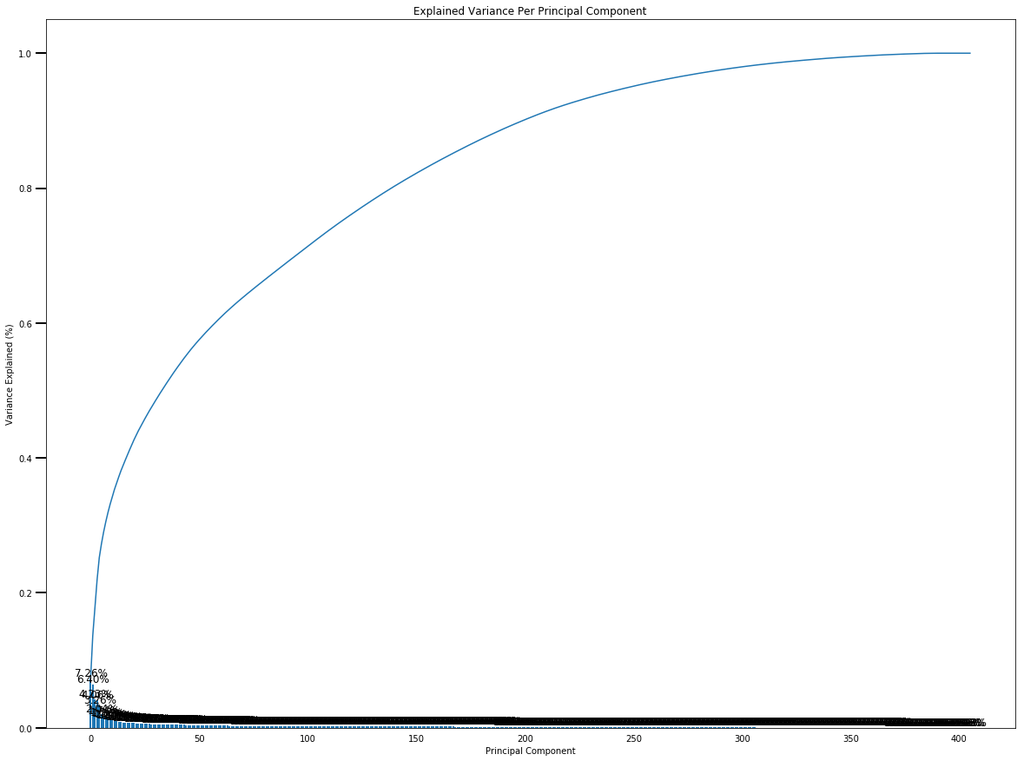

```python
# Investigate the variance accounted for by each principal component.

# create function for plotting the cumulative or sequential value
def scree_plot(pca):
    '''Creates a scree plot associated with the principal components

    Args:
    pca: Model. The result of instantian of PCA in scikit learn

    OUTPUT:
    scree plot. plot. results of pca
    '''

    num_components=len(pca.explained_variance_ratio_)
    ind = np.arange(num_components)
    vals = pca.explained_variance_ratio_

    plt.figure(figsize=(20, 15))
    ax = plt.subplot(111)
    cumvals = np.cumsum(vals)
    ax.bar(ind, vals)
    ax.plot(ind, cumvals)
    for i in range(num_components):
        ax.annotate(r"%s%%" % ((str(vals[i]*100)[:4])), (ind[i]+0.2, vals[i]), va="bottom", ha="center", fontsize=12)

    ax.xaxis.set_tick_params(width=0)
    ax.yaxis.set_tick_params(width=2, length=12)

    ax.set_xlabel("Principal Component")
    ax.set_ylabel("Variance Explained (%)")
    plt.title('Explained Variance Per Principal Component')

# plotting the cumulative or sequential value
scree_plot(pca)
```

> From the plot above, we can see that the amount of variability explained by principal component start to slow down from 40th principal components and the accumulative variance explained also showed that the increaseing rate is approximately constant. Therefore, we selected 40 for the PCA as the number of component.

```python
# Re-apply PCA to the data while selecting for number of components to retain.
pca = PCA(n_components=40)
azdias_pca = pca.fit_transform(df_azdias_scaled)
```

## Part 1: Customer Segmentation Report

The main bulk of your analysis will come in this part of the project. Here, you should use unsupervised learning techniques to describe the relationship between the demographics of the company's existing customers and the general population of Germany. By the end of this part, you should be able to describe parts of the general population that are more likely to be part of the mail-order company's main customer base, and which parts of the general population are less so.

### 1.1: Apply Clustering to General Population

```python
# Over a number of different cluster counts...
# run k-means clustering on the data and...
# compute the average within-cluster distances.

#   create function to obtain kmean score
def get_kmeans_score(data, center):
    '''
    returns the kmeans score regarding SSE for points to centers
    INPUT:
        data - the dataset you want to fit kmeans to
        center - the number of centers you want (the k value)
    OUTPUT:
        score - the SSE score for the kmeans model fit to the data
    '''
    #instantiate kmeans
    kmeans = KMeans(n_clusters=center)

    # Then fit the model to your data using the fit method
    model = kmeans.fit(data)

    # Obtain a score related to the model fit
    score = np.abs(model.score(data))

    return score

# create empty list for scores
scores = []

# let's try for 1 to 12 with every 1 steps
centers = list(range(1,12,1))

# loop for all centers and get kmeans score by using function "get_kmeans_score"
for center in centers:
    scores.append(get_kmeans_score(azdias_pca, center))
```

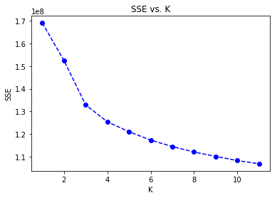

```python
# Investigate the change in within-cluster distance across number of clusters.
# Use matplotlib's plot function to visualize this relationship.

plt.plot(centers, scores, linestyle='--', marker='o', color='b');
plt.xlabel('K');
plt.ylabel('SSE');
plt.title('SSE vs. K')
```

> At k=4 point, adding new clusters will no longer create a substantial decrease in the average distance. This point is known as the elbow. Therefore, 4 clusters should be used for k-mean model to identify segment general population.

```python
# Re-fit the k-means model with the selected number of clusters and obtain
# cluster predictions for the general population demographics data.

# Try instantiating a model with n_clusters=4
kmeans = KMeans(n_clusters=4)

# Then fit the model to the data using the fit method
model = kmeans.fit(azdias_pca)

# perform prediction for general population
azdias_prediction = model.predict(azdias_pca)
```

### 1.2: Apply All Steps to Customers Data (Handling Missing Data, Data Preprocessing, Clustering Modelling)

```python
# load customers datasets
customers = pd.read_csv('data/Udacity_CUSTOMERS_052018.csv')
```

```python
# As mentioned above, the customers datasets contains three extra columns ('CUSTOMER_GROUP', 'ONLINE_PURCHASE', and 'PRODUCT_GROUP').
# drop these three addition columns from customer datasets
customers_drop = customers.drop(['CUSTOMER_GROUP', 'ONLINE_PURCHASE', 'PRODUCT_GROUP'], axis = 1)
```

```python
# cleaning missing data of customers datasets
df_customers = clean_missing_data(customers_drop)
```

```python
# Encoding features of customers datasets
df_customers = encode_feature(df_customers)
```

```python
# apply feature_scaling for df_customer and save as "customer_scaled"
customers_scaled = scaler.transform(df_customers)
```

```python
# perform dimensionality reduction (PCA) for customer_scaled
customers_pca = pca.transform(customers_scaled)
```

```python
# perform prediction for customer population
customers_prediction = model.predict(customers_pca)
```

### 1.3: Comparison of the proportion of data in each cluster for the customer data and general population data

```python
# Compare the proportion of data in each cluster for the customer data to the
# proportion of data in each cluster for the general population.

#  function for calculating the proportion of customer and general populations
def calculate_prop(prediction):
    '''Calculating the proportion of customer and general populations

    Args:
    prediction. Array/Series. predicted results

    Return:
    lis. List. proportion of predicted results.

    '''
    lis = []
    for i in np.arange(0,4):
        prop = (prediction == i).sum()/len(prediction)
        lis.append(prop)
    return lis
```

```python
#  create empty DataFrame
df_compare = pd.DataFrame()

# insert cluster number (0 to 3)
df_compare['cluster'] = np.arange(0,4)

# insert all proportions of customer population for each cluster
df_compare['prop_customers']= calculate_prop(customers_prediction)

# insert all proportions of general population for each cluster
df_compare['prop_azdias']= calculate_prop(azdias_prediction)
```

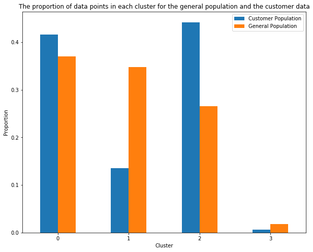

```python
# plotting cluster bar chart by using pandas's plot()
df_compare.plot(x='cluster', y = ['prop_customers', 'prop_azdias'], kind='bar', figsize=(10,8))

# insert title, y-label, x-label
plt.title('The proportion of data points in each cluster for the general population and the customer data')
plt.ylabel('Proportion')
plt.xlabel('Cluster')

# rename legend
L=plt.legend()
L.get_texts()[0].set_text('Customer Population')
L.get_texts()[1].set_text('General Population')

# rotate xticks
plt.xticks(rotation=0);
```

#### 1.3.1: Which cluster or clusters are overrepresented and underrepresented in the customer dataset compared to the general population?

```python
df_compare['prop_customers-prop_azdias'] = df_compare['prop_customers']- df_compare['prop_azdias']
df_compare
```

|  | cluster | prop_customers | prop_azdias | prop_customers-prop_azdias |
| --- | --- | --- | --- | --- |
| 0 | 0 | 0.416165 | 0.369480 | 0.046685 |
| 1 | 1 | 0.135700 | 0.347350 | -0.211651 |
| 2 | 2 | 0.441725 | 0.265274 | 0.176451 |
| 3 | 3 | 0.006410 | 0.017896 | -0.011486 |

Let's find out what kind of people might be represented by clusters 2 and 1, which have highest overrepresented and underrepresented respectively.

#### 1.3.2: What kind of people might be represented by clusters 2 (highest overrepresented) and 1 (highest underrepresented)

```python
# create function for inverse transform PCA and plotting
def plot_scaled_comparison(df, cluster):
    '''inverse transform PCA and plotting

    Arg:
    df. DataFrame. orginal dataframe which have completed features column name
    cluster. Integer. cluster number

    Return:
    None. Plotting Horizontal Bar Chart
    '''

    X = pd.DataFrame.from_dict(dict(zip(df.columns, pca.inverse_transform(kmeans.cluster_centers_[cluster]))), orient='index').rename(
    columns={0: 'feature_values'}).sort_values('feature_values', ascending=False)

    pd.concat((X['feature_values'][:10], X['feature_values'][-10:]), axis=0).plot(kind='barh', color = 'b');
```

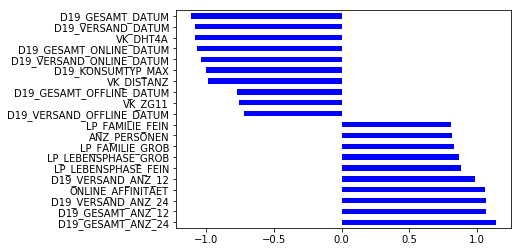

```python
# What kinds of people are part of a cluster that is overrepresented in the
# customer data compared to the general population?

# inverse transform and plotting for overrepresented cluster
plot_scaled_comparison(df_azdias, 2)
```

Obviously, the kind of people who from Cluster 2 (overrepresented in the customer data compared to the general population) have the following background information:

```
- higher activity of the last transaction with the complete file TOTAL (D19_GESAMT_DATUM)
- higher activity of the last transaction for the segment mail-order TOTAL (D19_VERSAND_DATUM)
- higher transaction activity TOTAL POOL in the last 24 months  (D19_GESAMT_ANZ_24)
- higher transaction activity TOTAL POOL in the last 12 months  (D19_GESAMT_ANZ_12)
```

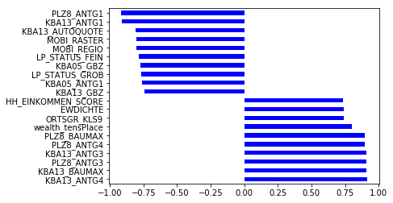

```python
# inverse transform and plotting for underrepresented cluster
plot_scaled_comparison(df_azdias, 1)
```

Obviously, the kind of people who from Cluster 1 (underrepresented in the customer data compared to the general population) have the following background information:

```
- lower number of 1-2 family houses (PLZ8_ANTG1)
- lower share of car owners (KBA13_ANTG1)
- higher number of cars (KBA13_ANTG4)
- higher share of cars built (KBA13_BAUMAX)
```

## Part 2: Supervised Learning Model

Now that you've found which parts of the population are more likely to be customers of the mail-order company, it's time to build a prediction model. Each of the rows in the "MAILOUT" data files represents an individual that was targeted for a mailout campaign. Ideally, we should be able to use the demographic information from each individual to decide whether or not it will be worth it to include that person in the campaign.

The "MAILOUT" data has been split into two approximately equal parts, each with almost 43 000 data rows. In this part, you can verify your model with the "TRAIN" partition, which includes a column, "RESPONSE", that states whether or not a person became a customer of the company following the campaign. In the next part, you'll need to create predictions on the "TEST" partition, where the "RESPONSE" column has been withheld.

### 2.1: Data Preprocessing of Mailout_Train Datasets

```python
# load mailout_train datasets
mailout_train = pd.read_csv('data/Udacity_MAILOUT_052018_TRAIN.csv')
```

```python
# cleaning missing data of mailout_train datasets
mailout_train = clean_missing_data(mailout_train)
```

```python
#  split train data to X_train and y_train
y_train = mailout_train.RESPONSE
X_train = mailout_train.drop(['RESPONSE'], axis = 1)
```

```python
# Encoding features of X_train datasets
X_train = encode_feature(X_train)
```

```python
# apply feature_scaling for X_train
X_train = scaler.transform(X_train)
```

```python
# perform dimensionality reduction (PCA) for X_train
X_train = pca.transform(X_train)
```

### 2.2: Model Evaluation (Model Selection)

```python
# As no 'RESPONSE' column of Mailout_Test Data were provided,
# let's split our Mailout_Train dataset into another subset of training ('train_val') and testing data ('test_val')
X_train_val, X_test_val, y_train_val, y_test_val = train_test_split(X_train, y_train, test_size = 0.2, random_state = 1)
```

```python
# Instantiate a number of our models
SGD_mod = SGDClassifier()
bag_mod = BaggingClassifier(n_estimators=200)
rf_mod = RandomForestClassifier(n_estimators=200)
ada_mod = AdaBoostClassifier(n_estimators=300, learning_rate=0.2)
svm_mod = SVC()
```

```python
# Fit each of the 5 models. These models need some time to run
SGD_mod.fit(X_train_val, y_train_val)
bag_mod.fit(X_train_val, y_train_val)
rf_mod.fit(X_train_val, y_train_val)
ada_mod.fit(X_train_val, y_train_val)
svm_mod.fit(X_train_val, y_train_val)
```

```
SVC(C=1.0, cache_size=200, class_weight=None, coef0=0.0,
  decision_function_shape='ovr', degree=3, gamma='auto_deprecated',
  kernel='rbf', max_iter=-1, probability=False, random_state=None,
  shrinking=True, tol=0.001, verbose=False)
```

```python
# Make predictions using each models
preds_SGD = SGD_mod.predict(X_test_val)
preds_bag = bag_mod.predict(X_test_val)
preds_rf = rf_mod.predict(X_test_val)
preds_ada = ada_mod.predict(X_test_val)
preds_svm = svm_mod.predict(X_test_val)
```

```python
def evaluate_model_results(y_test, preds, model_name = None):
    '''evaluate model results by classification report

    Args:
    y_test. array/series. correct labels for testing
    preds. array/series. predicted labels for X_test data
    model_name. String. Default is None. Model Name

    Output:
    None. prints all results
    '''
    print('The Results for ' + model_name)
    print(classification_report(y_test, preds))
    print('-----------------------------------------------------')

# evaluate each model results
evaluate_model_results(y_test_val, preds_SGD, 'SGD')
evaluate_model_results(y_test_val, preds_bag, 'Bagging')
evaluate_model_results(y_test_val, preds_rf, 'Random Forest')
evaluate_model_results(y_test_val, preds_ada, 'AdaBoost')
evaluate_model_results(y_test_val, preds_svm, 'SVM')
```

```
The Results for SGD
              precision    recall  f1-score   support

           0       0.98      0.99      0.99      6897
           1       0.00      0.00      0.00       105

   micro avg       0.98      0.98      0.98      7002
   macro avg       0.49      0.50      0.49      7002
weighted avg       0.97      0.98      0.97      7002

-----------------------------------------------------
The Results for Bagging
              precision    recall  f1-score   support

           0       0.99      1.00      0.99      6897
           1       0.00      0.00      0.00       105

   micro avg       0.98      0.98      0.98      7002
   macro avg       0.49      0.50      0.50      7002
weighted avg       0.97      0.98      0.98      7002

-----------------------------------------------------
The Results for Random Forest
              precision    recall  f1-score   support

           0       0.99      1.00      0.99      6897
           1       0.00      0.00      0.00       105

   micro avg       0.99      0.99      0.99      7002
   macro avg       0.49      0.50      0.50      7002
weighted avg       0.97      0.99      0.98      7002

-----------------------------------------------------
The Results for AdaBoost
              precision    recall  f1-score   support

           0       0.99      1.00      0.99      6897
           1       0.00      0.00      0.00       105

   micro avg       0.99      0.99      0.99      7002
   macro avg       0.49      0.50      0.50      7002
weighted avg       0.97      0.99      0.98      7002

-----------------------------------------------------
The Results for SVM
              precision    recall  f1-score   support

           0       0.99      1.00      0.99      6897
           1       0.00      0.00      0.00       105

   micro avg       0.99      0.99      0.99      7002
   macro avg       0.49      0.50      0.50      7002
weighted avg       0.97      0.99      0.98      7002

-----------------------------------------------------
```

> Based on the results above, all models' F1 scores are comparable. Let's proceed for building and tuning AdaBoost Model.

### 2.3: Model Building, Tuning and Training

```python
# build a classifier for ada boost
clf_ada = AdaBoostClassifier()

# Set up the hyperparameter search
# look at  setting up your search for n_estimators, learning_rate
# http://scikit-learn.org/stable/modules/generated/sklearn.ensemble.AdaBoostClassifier.html
param_dist = {"n_estimators": [10, 200],
              "learning_rate": [0.001, 0.1, 1, 20]}

# Run a randomized search over the hyperparameters
# define model (will be used at Part 3 Kaggle Competition) for fit Mailout_Train and predict Mailout_Test
ada_search = RandomizedSearchCV(clf_ada, param_distributions=param_dist)

# define model (will be used at Part 2.4 Model Result Validation) for fit X_train_val and predict X_test_val
ada_search_val = RandomizedSearchCV(clf_ada, param_distributions=param_dist)
```

```python
# Fit the model on the training data
ada_search.fit(X_train, y_train)
```

```
RandomizedSearchCV(cv='warn', error_score='raise-deprecating',
          estimator=AdaBoostClassifier(algorithm='SAMME.R', base_estimator=None,
          learning_rate=1.0, n_estimators=50, random_state=None),
          fit_params=None, iid='warn', n_iter=10, n_jobs=None,
          param_distributions={'n_estimators': [10, 200], 'learning_rate': [0.001, 0.1, 1, 20]},
          pre_dispatch='2*n_jobs', random_state=None, refit=True,
          return_train_score='warn', scoring=None, verbose=0)
```

### 2.4: Model Result Validation

```python
# Fit the model on X_train_val, y_train_val
ada_search_val.fit(X_train_val, y_train_val)
```

```
RandomizedSearchCV(cv='warn', error_score='raise-deprecating',
          estimator=AdaBoostClassifier(algorithm='SAMME.R', base_estimator=None,
          learning_rate=1.0, n_estimators=50, random_state=None),
          fit_params=None, iid='warn', n_iter=10, n_jobs=None,
          param_distributions={'n_estimators': [10, 200], 'learning_rate': [0.001, 0.1, 1, 20]},
          pre_dispatch='2*n_jobs', random_state=None, refit=True,
          return_train_score='warn', scoring=None, verbose=0)
```

```python
# Make predictions on the Customers Datasets
y_preds_val = ada_search_val.best_estimator_.predict(X_test_val)
```

```python
# evaluse model results by using y_test_val
evaluate_model_results(y_test_val, y_preds_val, 'AdaBoost')
```

```
The Results for AdaBoost
              precision    recall  f1-score   support

           0       0.99      1.00      0.99      6897
           1       0.00      0.00      0.00       105

   micro avg       0.99      0.99      0.99      7002
   macro avg       0.49      0.50      0.50      7002
weighted avg       0.97      0.99      0.98      7002

-----------------------------------------------------
```

## Part 3: Kaggle Competition

Now that you've created a model to predict which individuals are most likely to respond to a mailout campaign, it's time to test that model in competition through Kaggle. If you click on the link [here](http://www.kaggle.com/t/21e6d45d4c574c7fa2d868f0e8c83140), you'll be taken to the competition page where, if you have a Kaggle account, you can enter. If you're one of the top performers, you may have the chance to be contacted by a hiring manager from Arvato or Bertelsmann for an interview!

Your entry to the competition should be a CSV file with two columns. The first column should be a copy of "LNR", which acts as an ID number for each individual in the "TEST" partition. The second column, "RESPONSE", should be some measure of how likely each individual became a customer – this might not be a straightforward probability. As you should have found in Part 2, there is a large output class imbalance, where most individuals did not respond to the mailout. Thus, predicting individual classes and using accuracy does not seem to be an appropriate performance evaluation method. Instead, the competition will be using AUC to evaluate performance. The exact values of the "RESPONSE" column do not matter as much: only that the higher values try to capture as many of the actual customers as possible, early in the ROC curve sweep.

### 3.1: Data Preprocessing of Mailout_Test Datasets

```python
# load mailout_test datasets
mailout_test = pd.read_csv('data/Udacity_MAILOUT_052018_TEST.csv')
```

```python
# cleaning missing data of mailout_test datasets
mailout_test = clean_missing_data(mailout_test)
```

```python
# Encoding features of X_test datasets
X_test = encode_feature(mailout_test)
```

```python
# apply feature_scaling for X_test
X_test = scaler.transform(X_test)
```

```python
# perform dimensionality reduction (PCA) for X_test
X_test = pca.transform(X_test)
```

### 3.2: Model Prediction

```python
# Make predictions on the test data
y_preds = ada_search.best_estimator_.predict(X_test)
```

### 3.3: Preparing CSV File for Kaggle Competition

```python
# create empty DataFrame
df_csv_forKaggle = pd.DataFrame()
```

```python
# insert LNR into df_csv_forKaggle
df_csv_forKaggle['LNR'] = mailout_test['LNR']
```

```python
# insert predicted RESPONSE into df_csv_forKaggle
df_csv_forKaggle['RESPONSE'] = y_preds
```

```python
# check if the preparation is successful
df_csv_forKaggle.head()
```

|  | LNR | RESPONSE |
| --- | --- | --- |
| 0 | 1754 | 0 |
| 1 | 1770 | 0 |
| 2 | 1465 | 0 |
| 3 | 1470 | 0 |
| 4 | 1478 | 0 |

```python
# Observing the prediction results
df_csv_forKaggle.RESPONSE.value_counts()
```

```
0    35006
Name: RESPONSE, dtype: int64
```

> The output above show all predicted "RESPONSE" are 'zero', which no responses from all individual. This might not be a straightforward probability. As Mailout_Train datasets (Model Train Data) has a large output class imbalance, where most individuals did not respond to the mailout, as shown at below.

```python
# further investigate the count of Mailout_Train's RESPONSE feature
mailout_train.RESPONSE.value_counts()
```

```
0    34573
1      435
Name: RESPONSE, dtype: int64
```

```python
# check their proportional values
mailout_train.RESPONSE.value_counts()/mailout_train.shape[0]
```

```
0    0.987574
1    0.012426
Name: RESPONSE, dtype: float64
```

> Count and proportion of RESPONSE's '1' are 435 and 0.01 respectively. Both values are extermely lower than '0'. This finding shows that the train data provided has a large output class imbalance, where most individuals did not respond to the mailout.

```python
# save as csv file
df_csv_forKaggle.to_csv('csvFile_KaggleCompetition.csv', index = False)
```

## Part 4: Project Reporting

The following detailed project reporting sections are presented at my Medium blog post [Here](https://medium.com/@leehongchen/create-a-customer-segmentation-report-for-arvato-financial-solutions-99b1954dfd58).

1. Introduction
2. Data Understanding (Data Exploration/Visualization)
3. Data Preparation/ Preprocessing
4. Model Setup and Evaluation
5. Results
6. Conclusion

For all related code/file, you cound find them at my github repository [Here](https://github.com/leehongchen1985/Capstone-Project-Create-a-Customer-Segmentation-Report-for-Arvato-Financial-Services-).